# Analysis Of Regulation That Affect ASD By Cell Type

### 0. Introduction

이번 분석은 cell type에 specific하게 발현하는 유전자들이 어떠한 regulation의 영향을 더 지대하게 받는지 cell type별로 확인해보고자 한다. 먼저 cell type별로 regulation이 일어난 유전자의 갯수를 세어보고 그 중에서 cell type에 specific하게 발현하는 유전자의 갯수로 필터링 하여 특이 값을 보이는 cell type을 걸러내어 진행하였다. 그 후, 주어진 데이터의 표본의 수가 적기 때문에 ASD환자 모집단의 추정과 검정을 하기 위해서 t-test를 진행하여 그 결과를 확인하였다.

### 1. Data Loding

분석을 위해 Data-S4를 불러오고자 한다.

```r
library(tidyverse)
library(readxl)
library(ggrepel)
library(ggplot2)
library(cowplot)
d4 <- read_xls("aav8130_Data-S4.xls")
```

### 2. Data Analysis & Transformation

먼저, 데이터를 바꾸기 전에 load된 data가 어떠한 형태를 띄고있는지 확인해보도록 하자.

```r
head(d4)
```

| Cell type | gene ID | Gene name | Gene biotype | Fold change | Sample fold change | q value | correlation (bulk mRNA/bulkized nuclear RNA) | Epilepsy DEG | gene group | SFARI gene | Satterstrom | Sanders | cell type-specific expression |
| --- | --- | --- | --- | --- | --- | --- | --- | --- | --- | --- | --- | --- | --- |
| L2/3 | ENSG00000116830 | TTF2 | protein_coding | -0.2263279 | -0.8440443 | 3.870510e-05 | 0.21598395220359112 | yes | group I | no | no | no | no |
| L2/3 | ENSG00000183486 | MX2 | protein_coding | -0.1589944 | -1.1595522 | 6.999077e-05 | -0.034721299759704047 | no | group I | no | no | no | no |
| L2/3 | ENSG00000138303 | ASCC1 | protein_coding | -0.1699755 | -0.4284487 | 1.172638e-04 | 0.35601883626631353 | no | group I | no | no | no | no |
| L2/3 | ENSG00000145451 | GLRA3 | protein_coding | 0.2458418 | 0.3968136 | 1.525338e-04 | 0.51335956747846367 | no | group V | no | no | no | no |
| L2/3 | ENSG00000099622 | CIRBP | protein_coding | -0.2184618 | -0.4513435 | 3.024188e-04 | 0.2473722042784588 | no | group III | no | no | no | no |
| L2/3 | ENSG00000141504 | SAT2 | protein_coding | -0.2356147 | -0.7958851 | 4.962561e-04 | 0.28799586697696894 | yes | group II | no | no | no | no |

이 dataset에서 먼저 cell type별로 보기 위해서 neuronal cell인지 nonneuronal cell인지 구분할 수 있는 column을 만들고, DEG의 달라진 expression정도를 보기 위해 Fold change값에 절댓값을 씌운 column을 추가할 것이다. 또한 절댓값을 씌운 것 때문에 upregulate 혹은 downregulate된 gene들의 구분이 어려워질 수 있으므로 어떤 방향으로 regulate가 일어났는지 표시할 수 있는 column을 만들고 cell type에 specific하게 발현하는 gene들은 따로 표시하려고 한다. 후에 있을 regulation숫자를 대입하고자 cell type별로 regulation 개수에 관한 행도 추가해주자.

```r
neuronal_cell <-  c("L2/3","L4","L5/6","L5/6-CC","IN-PV","IN-SST","IN-VIP","IN-SV2C","Neu-NRGN-I","Neu-NRGN-II","Neu-mat")
k <- d4 %>% count(`Cell type`)
c <- c()
for (i in c(1:length(d4$`Cell type`))) {
  for (j in c(1:length(k$`Cell type`))) {
    if (d4$`Cell type`[i] != k$`Cell type`[j]) {
      next}
    else {
      c <- append(c, k$`n`[j])
    }
  }
}
p <- d4 %>% filter(`cell type-specific expression` == 'yes') %>% group_by(`Cell type`) %>% count(`cell type-specific expression`)
x <- c()
for (i in c(1:length(d4$`Cell type`))) {
  count <- 0
  for (j in c(1:length(p$`Cell type`))) {
    if (d4$`Cell type`[i] != p$`Cell type`[j]) {
      count <- count + 1
      if (count == length(p$`Cell type`)) {
        x <- append(x, NA)}
      next}
    else {
      x <- append(x, p$`n`[j])
    }
  }
}
m_d4 <- d4 %>%
  mutate(neuronal_or_nonneuronal = ifelse(d4$`Cell type` %in% neuronal_cell,'neuronal','non-neuronal'), 'abs Fold change'=abs(`Fold change`), regulating = ifelse(.$`Fold change`>0,'upregulate','downregulate')) %>%
  mutate(regulating = ifelse(`cell type-specific expression` == "yes", paste(regulating,"cell_type_specific",sep ="_"),regulating)) %>% mutate(n=c) %>% mutate(ns=x)

u <- c()
for (i in c(1:length(k$`Cell type`))) {
  count <- 0
  for (j in c(1:length(p$`Cell type`))) {
    if (k$`Cell type`[i] != p$`Cell type`[j]) {
      count <- count + 1
      if (count == length(p$`Cell type`)) {
        u <- append(u, NA)}
      next}
    else {
      u <- append(u, p$`n`[j])
    }
  }
}
kn <- k %>% mutate(ns = u, neuronal_or_nonneuronal = ifelse(k$`Cell type` %in% neuronal_cell,'neuronal','non-neuronal'))
head(m_d4)
```

| Cell type | gene ID | Gene name | Gene biotype | Fold change | Sample fold change | q value | correlation (bulk mRNA/bulkized nuclear RNA) | Epilepsy DEG | gene group | SFARI gene | Satterstrom | Sanders | cell type-specific expression | neuronal_or_nonneuronal | abs Fold change | regulating | n | ns |
| --- | --- | --- | --- | --- | --- | --- | --- | --- | --- | --- | --- | --- | --- | --- | --- | --- | --- | --- |
| L2/3 | ENSG00000116830 | TTF2 | protein_coding | -0.2263279 | -0.8440443 | 3.870510e-05 | 0.21598395220359112 | yes | group I | no | no | no | no | neuronal | 0.2263279 | downregulate | 109 | 5 |
| L2/3 | ENSG00000183486 | MX2 | protein_coding | -0.1589944 | -1.1595522 | 6.999077e-05 | -0.034721299759704047 | no | group I | no | no | no | no | neuronal | 0.1589944 | downregulate | 109 | 5 |
| L2/3 | ENSG00000138303 | ASCC1 | protein_coding | -0.1699755 | -0.4284487 | 1.172638e-04 | 0.35601883626631353 | no | group I | no | no | no | no | neuronal | 0.1699755 | downregulate | 109 | 5 |
| L2/3 | ENSG00000145451 | GLRA3 | protein_coding | 0.2458418 | 0.3968136 | 1.525338e-04 | 0.51335956747846367 | no | group V | no | no | no | no | neuronal | 0.2458418 | upregulate | 109 | 5 |
| L2/3 | ENSG00000099622 | CIRBP | protein_coding | -0.2184618 | -0.4513435 | 3.024188e-04 | 0.2473722042784588 | no | group III | no | no | no | no | neuronal | 0.2184618 | downregulate | 109 | 5 |
| L2/3 | ENSG00000141504 | SAT2 | protein_coding | -0.2356147 | -0.7958851 | 4.962561e-04 | 0.28799586697696894 | yes | group II | no | no | no | no | neuronal | 0.2356147 | downregulate | 109 | 5 |

```r
head(kn)
```

| Cell type | n | ns | neuronal_or_nonneuronal |
| --- | --- | --- | --- |
| AST-FB | 15 | 4 | non-neuronal |
| AST-PP | 60 | 9 | non-neuronal |
| Endothelial | 60 | 12 | non-neuronal |
| IN-PV | 28 | 4 | neuronal |
| IN-SST | 29 | 3 | neuronal |
| IN-SV2C | 32 | 1 | neuronal |

### 3. Data Visualization & Analysis

변형한 dataset에서 cell type별로 전체 regulation의 숫자를 count하고 cell type에 specific한 regulation의 숫자로 count하여 filtering을 한 결과로 특이점을 보이는 cell type을 보고자 한다.

```
Removed 3 rows containing non-finite values (stat_smooth).Removed 3 rows containing missing values (geom_point).Removed 3 rows containing missing values (geom_text_repel).`geom_smooth()` using formula 'y ~ x'
Removed 3 rows containing non-finite values (stat_smooth).Removed 3 rows containing missing values (geom_point).Removed 3 rows containing missing values (geom_text_repel).`geom_smooth()` using formula 'y ~ x'
```

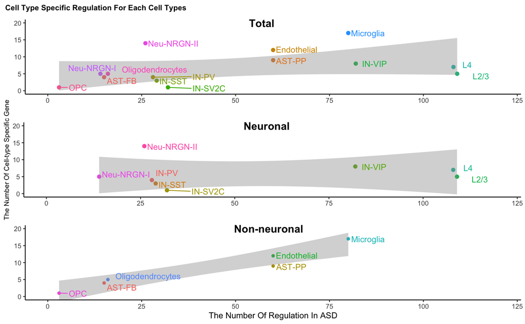

```r
plot_grid(ggdraw() +
            draw_label(
              "Cell Type Specific Regulation For Each Cell Types", size = 10,
              fontface ='bold', x = 0, hjust=0) +
            theme(plot.margin = margin(0,0,0,7)),
          ggplot(kn, aes(x=n, y=ns, label = `Cell type`)) +
            geom_point(aes(color = `Cell type`), size =2) +
            geom_smooth(method = lm, colour = 0.5) +
            geom_text_repel(aes(color = `Cell type`), nudge_x = 5, nudge_y = -0.02) +
            theme_classic() +
            theme(legend.position = "none") +
            coord_cartesian(xlim = c(0,120), ylim = c(0, 20)) +
            labs(x = "", y = ""),
          ggplot(kn %>% filter(neuronal_or_nonneuronal == 'neuronal'),
                 aes(x=n, y=ns, label = `Cell type`)) +
            geom_point(aes(color = `Cell type`), size =2) +
            geom_smooth(method = lm, colour = 0.5) +
            geom_text_repel(aes(color = `Cell type`), nudge_x = 5, nudge_y = -0.05) +
            theme_classic() +
            theme(legend.position = "none", axis.title.y = element_text(size =9)) +
            coord_cartesian(xlim = c(0,120), ylim = c(0,20)) +
            labs(x = "", y = "The Number Of Cell-type Specific Gene"),
          ggplot(kn %>%
                   filter(neuronal_or_nonneuronal == 'non-neuronal'),
                 aes(x=n, y=ns, label = `Cell type`)) +
            geom_point(aes(color = `Cell type`)) +
            geom_smooth(method = lm, colour =0.5) +
            geom_text_repel(aes(color = `Cell type`), nudge_x = 5, nudge_y = -0.05) +
            theme_classic() +
            theme(legend.position = "none") +
            coord_cartesian(xlim = c(0,120), ylim = c(0,20)) +
            labs(x ="The Number Of Regulation In ASD", y=""),
          ncol =1,
          labels = c("","Total","Neuronal","Non-neuronal"),
          label_x = c(0, 0.45, 0.42, 0.38),
          rel_heights = c(0.3,2,2,2,0.2),
          scale =1)
```

`Microglia`, `Endothelial`, `Neu-NRGN-II`, `IN-SV2C`, `AST-PP` 5가지의 cell type에서 특이점을 보이는 것을 확인하였다. 특이점이 있는 5가지의 cell type별로 어떤 regulation(up, down)이 더 지대한 영향을 미치는지 알아보고자 한다. 주어진 표본의 수가 적으니 t분포를 통해 유의확률 5%에서 검정해보자. 귀무가설을 세우기에 앞서서 각 cell type별로 어떤 regulation이 높게 나오는지 확인해보자. 이를 위해, 변형한 dataset에서 cell type 별로 어떠한 방향으로 regulate된 gene들의 발현량이 높은지, regulate 방향에 따라 절댓값이 씌워진 Fold change의 **대푯값**을 통해 확인하고자 한다.

**대푯값**을 설정하기 전에 절댓값을 씌운 Fold change값의 범위, 평균을 통해 절댓값을 씌운 Fold change의 분산을 살펴보고자 한다.

```r
range(m_d4$`abs Fold change`)
```

```
[1] 0.1401016 0.8419946
```

```r
mean(m_d4$`abs Fold change`)
```

```
[1] 0.2362021
```

넓은 범위에 비해 낮은 평균값을 보임을 통해 절댓값을 씌운 Fold change값에 outlier가 있음을 예측할 수 있다. 따라서 대푯값은 **Median**으로 설정하는 것이 바람직하다.

귀무가설을 세우기 위해 **Median**값으로 regulation에 따른 발현량의 차이를 살펴보고, 각각의 cell type에서 cell type specific한 regulation의 숫자를 살펴보자.

```r
rm_d4 <- m_d4 %>% filter(regulating %in% c("upregulate_cell_type_specific","downregulate_cell_type_specific"), `Cell type` %in% c('Microglia', 'Endothelial', 'Neu-NRGN-II', 'IN-SV2C', 'AST-PP')) %>% group_by(`Cell type`,regulating,neuronal_or_nonneuronal) %>%
  summarize(mid = median(`abs Fold change`))
rm_d4
```

| Cell type | regulating | neuronal_or_nonneuronal | mid |
| --- | --- | --- | --- |
| AST-PP | downregulate_cell_type_specific | non-neuronal | 0.8039983 |
| AST-PP | upregulate_cell_type_specific | non-neuronal | 0.2682357 |
| Endothelial | downregulate_cell_type_specific | non-neuronal | 0.3408996 |
| Endothelial | upregulate_cell_type_specific | non-neuronal | 0.5103145 |
| IN-SV2C | upregulate_cell_type_specific | neuronal | 0.1917824 |
| Microglia | downregulate_cell_type_specific | non-neuronal | 0.3791776 |
| Microglia | upregulate_cell_type_specific | non-neuronal | 0.3552398 |
| Neu-NRGN-II | downregulate_cell_type_specific | neuronal | 0.3927361 |
| Neu-NRGN-II | upregulate_cell_type_specific | neuronal | 0.2646796 |

```r
m_d4 %>% filter(regulating %in% c("upregulate_cell_type_specific","downregulate_cell_type_specific"), `Cell type` %in% c('Microglia', 'Endothelial', 'Neu-NRGN-II', 'IN-SV2C', 'AST-PP')) %>% group_by(`Cell type`) %>% count(regulating)
```

| Cell type | regulating | n |
| --- | --- | --- |
| AST-PP | downregulate_cell_type_specific | 1 |
| AST-PP | upregulate_cell_type_specific | 8 |
| Endothelial | downregulate_cell_type_specific | 2 |
| Endothelial | upregulate_cell_type_specific | 10 |
| IN-SV2C | upregulate_cell_type_specific | 1 |
| Microglia | downregulate_cell_type_specific | 1 |
| Microglia | upregulate_cell_type_specific | 16 |
| Neu-NRGN-II | downregulate_cell_type_specific | 5 |
| Neu-NRGN-II | upregulate_cell_type_specific | 9 |

```r
NA
```

IN-SV2C는 upregulate밖에 없고 표본도 하나이기에 논지에서 제외한다.

이를 통해 귀무가설과 대립가설을 세워보면 다음과 같다.

*H0 : upregulate가 downregulate보다 영향을 많이 미친다.*(AST-PP, Microglia, Neu-NRGN-II)

*H0 : downregulate가 upregulate보다 영향을 많이 미친다.*(Endothelial)

*H1 : downregulate가 upregulate보다 영향을 많이 미친다.*(AST-PP, Microglia, Neu-NRGN-II)

*H1 : upregulate가 downregulate보다 영향을 많이 미친다.*(Endothelial)

이것을 바탕으로 4개의 cell type에 따라 t검정을 진행해보자.

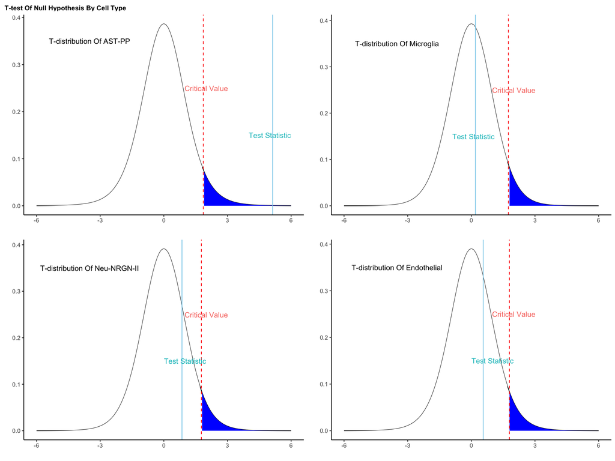

```r
l_AST_u <- m_d4 %>% select(`Cell type`,`abs Fold change`,`cell type-specific expression`, regulating) %>% filter(`cell type-specific expression`=='yes', `Cell type` == 'AST-PP', regulating == 'upregulate_cell_type_specific') %>% pull(`abs Fold change`)
l_AST_d <- m_d4 %>% select(`Cell type`,`abs Fold change`,`cell type-specific expression`, regulating) %>% filter(`cell type-specific expression`=='yes', `Cell type` == 'AST-PP', regulating == 'downregulate_cell_type_specific') %>% pull(`abs Fold change`)
l_Mic_u <- m_d4 %>% select(`Cell type`,`abs Fold change`,`cell type-specific expression`,regulating) %>% filter(`cell type-specific expression`=='yes', `Cell type` == 'Microglia', regulating == 'upregulate_cell_type_specific') %>% pull(`abs Fold change`)
l_Mic_d <- m_d4 %>% select(`Cell type`,`abs Fold change`,`cell type-specific expression`,regulating) %>% filter(`cell type-specific expression`=='yes', `Cell type` == 'Microglia', regulating == 'downregulate_cell_type_specific') %>% pull(`abs Fold change`)
l_Neu_u <- m_d4 %>% select(`Cell type`,`abs Fold change`,`cell type-specific expression`,regulating) %>% filter(`cell type-specific expression`=='yes', `Cell type` == 'Neu-NRGN-II',regulating == 'upregulate_cell_type_specific') %>% pull(`abs Fold change`)
l_Neu_d <- m_d4 %>% select(`Cell type`,`abs Fold change`,`cell type-specific expression`,regulating) %>% filter(`cell type-specific expression`=='yes', `Cell type` == 'Neu-NRGN-II',regulating == 'downregulate_cell_type_specific') %>% pull(`abs Fold change`)
l_End_u <- m_d4 %>% select(`Cell type`,`abs Fold change`,`cell type-specific expression`,regulating) %>% filter(`cell type-specific expression`=='yes', `Cell type` == 'Endothelial',regulating == 'upregulate_cell_type_specific') %>% pull(`abs Fold change`)
l_End_d <-  m_d4 %>% select(`Cell type`,`abs Fold change`,`cell type-specific expression`,regulating) %>% filter(`cell type-specific expression`=='yes', `Cell type` == 'Endothelial',regulating == 'downregulate_cell_type_specific') %>% pull(`abs Fold change`)

mu_AST = 0
xbar_AST = mean(l_AST_d) - mean(l_AST_u)
sd_AST = sqrt(0 + sd(l_AST_u)/8)
lu_AST = qt(0.95, df = 8)
v_t_AST = (xbar_AST-mu_AST)/sd_AST

mu_Mic = 0
xbar_Mic = mean(l_Mic_d) - mean(l_Mic_u)
sd_Mic = sqrt(0 + sd(l_Mic_u)/16)
lu_Mic = qt(0.95, df=16)
v_t_Mic = (xbar_Mic-mu_Mic)/sd_Mic

mu_Neu = 0
xbar_Neu = mean(l_Neu_d) - mean(l_Neu_u)
sd_Neu = sqrt(sd(l_Neu_d)/5 + sd(l_Neu_u)/9)
lu_Neu = qt(0.95, df=13)
v_t_Neu = (xbar_Neu-mu_Neu)/sd_Neu

mu_End = 0
xbar_End = mean(l_End_u) - mean(l_End_d)
sd_End = sqrt(sd(l_Neu_u)/10 + sd(l_Neu_d)/2)
lu_End = qt(0.95, df=11)
v_t_End = (xbar_End-mu_End)/sd_End


df_AST <- data.frame(x=seq(-6, 6, 0.1), pdf=dt(x=seq(-6, 6, 0.1),df=8)) %>% mutate(p_val= ifelse(x>=lu_AST,"blue","white"))
df_End <- data.frame(x=seq(-6, 6, 0.1), pdf=dt(x=seq(-6, 6, 0.1),df=11)) %>% mutate(p_val=ifelse(x>=lu_End,"blue","white"))
df_Mic <- data.frame(x=seq(-6, 6, 0.1), pdf=dt(x=seq(-6, 6, 0.1),df=16)) %>% mutate(p_val=ifelse(x>=lu_Mic,"blue","white"))
df_Neu <- data.frame(x=seq(-6, 6, 0.1), pdf=dt(x=seq(-6, 6, 0.1),df=13)) %>% mutate(p_val=ifelse(x>=lu_Neu,"blue","white"))

plot_grid(ggdraw() +
            draw_label(
              "T-test Of Null Hypothesis By Cell Type", size = 10,
              fontface ='bold', x = 0, hjust=0, vjust=1) +
            theme(plot.margin = margin(0,0,0,7)),
          ggdraw() + draw_label("", size = 10,
              fontface ='bold', x = 0, hjust=0, vjust=1) +
            theme(plot.margin = margin(0,0,0,7)),
ggplot(df_AST, aes(x=x, y=pdf)) +
   geom_line() + theme_classic() +
  geom_area(aes(fill=p_val)) +
  scale_fill_manual(values=c("blue","white")) +
  geom_vline(xintercept=c(lu_AST,v_t_AST), linetype = c("dashed","solid"), color= c("red","skyblue")) +
  theme(legend.position = "none") +
  geom_text(data=data.frame(x= c(2,5), y = c(0.25,0.15)), mapping = aes(x,y,label=c("Critical Value","Test Statistic"), color = c("darkblue","red"))) +
  labs(x="",y="")+
  geom_text(data = data.frame(x=-3.5,y=0.35), mapping = aes(x,y,label = "T-distribution Of AST-PP")),
ggplot(df_Mic, aes(x=x, y=pdf)) +
   geom_line() + theme_classic() +
  geom_area(aes(fill=p_val)) +
  scale_fill_manual(values=c("blue","white")) +
  geom_vline(xintercept=c(lu_Mic,v_t_Mic), linetype = c("dashed","solid"), color= c("red","skyblue")) +
  theme(legend.position = "none") +
  geom_text(data=data.frame(x= c(2,0.1), y = c(0.25,0.15)), mapping = aes(x,y,label=c("Critical Value","Test Statistic"), color = c("darkblue","red"))) +
  labs(x="",y="") +
  geom_text(data = data.frame(x=-3.5,y=0.35), mapping = aes(x,y,label = "T-distribution Of Microglia")),
ggplot(df_Neu, aes(x=x, y=pdf)) +
   geom_line() + theme_classic() +
  geom_area(aes(fill=p_val)) +
  scale_fill_manual(values=c("blue","white")) +
  geom_vline(xintercept=c(lu_Neu,v_t_Neu), linetype = c("dashed","solid"), color= c("red","skyblue")) +
  theme(legend.position = "none") +
  geom_text(data=data.frame(x= c(2,1), y = c(0.25,0.15)), mapping = aes(x,y,label=c("Critical Value","Test Statistic"), color = c("darkblue","red"))) +
  labs(x="",y="") +
  geom_text(data = data.frame(x=-3.5,y=0.35), mapping = aes(x,y,label = "T-distribution Of Neu-NRGN-II")),
ggplot(df_End, aes(x=x, y=pdf)) +
   geom_line() + theme_classic() +
  geom_area(aes(fill=p_val)) +
  scale_fill_manual(values=c("blue","white")) +
  geom_vline(xintercept=c(lu_End,v_t_End), linetype = c("dashed","solid"), color= c("red","skyblue")) +
  theme(legend.position = "none") +
  geom_text(data=data.frame(x= c(2,1), y = c(0.25,0.15)), mapping = aes(x,y,label=c("Critical Value","Test Statistic"), color = c("darkblue","red"))) +
  labs(x="",y="") +
  geom_text(data = data.frame(x=-3.5,y=0.35), mapping = aes(x,y,label = "T-distribution Of Endothelial")), ncol=2,rel_heights = c(0.05,1,1))
```

### 4. Conclusion

t-test결과 분포를 살펴보면, 5% 유의확률에서 오직 AST-PP만 귀무가설을 기각하고 나머지 3가지의 cell type에서는 귀무가설을 기각하지 않는 것을 볼 수 있다. 따라서 cell specific하게 유전자 발현이 일어나는 유전자들 중에 AST-PP와 Endothelial cell type에서는 downregulation의 양가 upregulation의 양보다 ASD환자에게 더 큰 영향을 미치고, Microglia와 Neu-NRGN-II cell type에서는 upregulation의 양이 downregulation의 양보다 ASD환자에게 더 큰 영향을 미친다는 결론을 지을 수 있다.

### 5. Revision

1. 먼저 저번에 잘 하지 못하였던 질문과 데이터 시각화 결과물과의 연관성을 높임과 동시에 순환논리를 벗어나고자 plot을 전부 변경하였고, 주제를 약간 다른 방식으로 잡아서 그 연계성을 높이고자 하였다.
2. 이전 plot은 복잡하고 난해하여 plot이 한눈에 들어오기 어려웠으며 내용 이해도 쉽지 않았다. 이번에는 ’이동찬’학우님의 저번 중간 포트폴리오에 영감을 받아서 한눈에 들어오기 쉬우며 더 의미있는 데이터 시각화를 하기 위해 노력하였다.
3. 저번 과제물에서는 plot이 2개보다 많았었지만 이번에는 tidy하게 두개의 plot으로 만들었다. 또한 t분포 plot을 공부해보고 직접 시도해봄으로써 새로운 plot방식에 접근해보고자 노력하였다.
4. 저번 plot에서는 채도가 약한 색을 사용하여 가시성이 떨어진다는 피드백을 받고 이번에는 강렬한 원색도 사용해보았다.
5. 어떤 것을 구분지을 때는 특정한 표시를 해서(빗금 등) 표현하면 더 좋겠다고 피드백을 받아서, 이번 t분포 geom_line의 유의확률 부분에 색을 넣고 vertical line을 설정하여 각각이 어떤 것을 의미하는지 더욱 쉽게 보이게끔 하였다.